# Positive or Negative?

This project is mainly about sentiment analysis on presidents’ inaugural speech. I want to know whether a president is more positive or more negative. By utilizing R package - sentiment, I chose three sentiments including positive, negative and neutral to see the percentile each sentiment accounts for in a speech.

Generally, a president is more positive in his inaugural speech. However, there are two exceptional cases. One is James Madison on his second inaugural speech, the other is Abraham Lincoln on his second inaugural speech. These two turn out to be more negative cases. Thus, I take these two cases for deepen analysis to see if I can find something illuminating in these speeches.

# Step 0: check and install needed packages. Load the libraries and functions.

```r
setwd("~/GitHub/Spr2017-Proj1-Senyao-Han")
```

```r
packages.used=c("rvest", "tibble", "qdap",
                "sentimentr", "gplots", "dplyr",
                "tm", "syuzhet", "factoextra",
                "beeswarm", "scales", "RColorBrewer",
                "RANN", "topicmodels", "rJava", "wordcloud", "reshape2")
# check packages that need to be installed.
packages.needed=setdiff(packages.used,
                        intersect(installed.packages()[,1],
                                  packages.used))
# install additional packages
if(length(packages.needed)>0){
  install.packages(packages.needed, dependencies = TRUE)
}
# load packages
library("rvest")
library("rJava")
library("tibble")
library("qdap")
library("gplots")
library("dplyr")
library("tm")
library("syuzhet")
library("factoextra")
library("beeswarm")
library("scales")
library("RColorBrewer")
library("RANN")
library("topicmodels")
library("wordcloud")
library("reshape2")
source("../lib/plotstacked.R")
source("../lib/speechFuncs.R")
```

```r
install.packages("../lib/sentiment_0.1.tar.gz", repos = NULL, type="source")
library(sentiment)
```

# Step 1: Data harvest: scrap speech URLs.

For this project, we selected all inaugural addresses of past presidents.

```r
### Inauguaral speeches
main.page <- read_html(x = "http://www.presidency.ucsb.edu/inaugurals.php")
# Get link URLs
# f.speechlinks is a function for extracting links from the list of speeches.
inaug=f.speechlinks(main.page)
#head(inaug)
# as.Date(inaug[,1], format="%B %e, %Y")
inaug=inaug[-nrow(inaug),] # remove the last line, irrelevant due to error.
```

# Step 2: Using speech metadata, we prepared CSV data sets for the speeches we will scrap.

```r
inaug.list=read.csv("../data/inauglist.csv", stringsAsFactors = FALSE)
colnames(inaug.list)<-c("President", "File", "Term", "Party", "Date", "Words", "Win")
```

# Step 3: scrap the texts of speeches from the speech URLs.

```r
speeches.list=inaug.list
speeches.list$type=rep("inaug", nrow(inaug.list))
speeches.url=inaug
speeches.list=cbind(speeches.list, speeches.url)
```

```r
# Loop over each row in speech.list
speeches.list$fullspeeches=NA
for(i in seq(nrow(speeches.list))) {
  text <- read_html(speeches.list$urls[i]) %>% # load the page
    html_nodes(".displaytext") %>% # isloate the text
    html_text() # get the text
  speeches.list$fullspeeches[i]=text
  # Create the file name
  filename <- paste0("../data/InauguralSpeeches/",
                     speeches.list$type[i],
                     speeches.list$File[i], "-",
                     speeches.list$Term[i], ".txt")
  sink(file = filename) %>% # open file to write
  cat(text)  # write the file
  sink() # close the file
}
```

# Step 4: data Processing — generate list of sentences and corresponding sentiments

We will use sentences as units of analysis for this project, as sentences are natural languge units for organizing thoughts and ideas. For each extracted sentence, we apply sentiment analysis using R package-sentiment. This package has a list of English words and their associations with six basic emotions (anger, fear, disgust, surprise, sadness and joy) and three sentiments (negative, positive and neutral).

In this case, my analysis only focuses on three sentiments.

We assign an sequential id to each sentence in a speech (`sent.id`) and also calculated the number of words in each sentence as *sentence length* (`word.count`).

```r
sentence.list1=NULL
for(i in 1:nrow(speeches.list)){
  sentences1=sent_detect(speeches.list$fullspeeches[i],
                        endmarks = c("?", ".", "!", "|",";"))
  if(length(sentences1)>0){
    # generate postive or negative or neutral sentiment
    class_pol2 = classify_polarity(sentences1, algorithm="bayes")
    polarity2 = class_pol2[,4]
    word.count=word_count(sentences1)
    # colnames(emotions)=paste0("emo.", colnames(emotions))
    # in case the word counts are zeros?
    sentence.list1=rbind(sentence.list1,
                        cbind(speeches.list[i,-ncol(speeches.list)],
                              sentences=as.character(sentences1),
                              polarity=polarity2,
                              word.count,
                              sent.id=1:length(sentences1)
                              )
    )
  }
}
```

```r
sentence.list1=
  sentence.list1%>%
  filter(!is.na(word.count))
```

# Step 5: Data analysis — sentiment analsis

## Create a dataframe consists of sentiments percentage for every president

```r
# create a function to calculate percentage for every sentiment
percentile<-function(x){
  as.data.frame(round(table(x)/length(x),2))
}
sentence.list1<-mutate(sentence.list1, Preterm=paste0(President, Term))
sentence.list1$Preterm<-factor(sentence.list1$Preterm)
sentipercent<-tapply(sentence.list1$polarity, sentence.list1$Preterm, percentile)
```

```r
# generate a data frame to store percentage we calculated above
sentidata<-c()
 for (i in 1:length(sentipercent)){
   sentidata<-rbind(sentidata, sentipercent[[i]][,2])
 }
sentidata<-as.data.frame(cbind(names(sentipercent), sentidata))
colnames(sentidata)<-c("Preterm", "Negative", "Neutral", "Positive")
orderdata<-as.data.frame(cbind(as.vector(unique(sentence.list1$Preterm)), 1:58))
colnames(orderdata)<-c("Preterm", "Order")
orderdata$Order<-as.numeric(as.character(orderdata$Order))
sentidata<-merge(orderdata,sentidata,by="Preterm")
sentidata2<-melt(sentidata, id=c("Preterm","Order"))
sentidata2<-sentidata2[order(sentidata2$Order),]
rownames(sentidata2)<-1:174
```

## How these three sentiments change for presidents in order?

We can see from the following graph that case 7 and case 20 are exceptional cases, in which percentage of negative sentiment is higher than the percentage of positive sentiment. Case 7 is James Madison on his second inaugural speech, case 20 is Abraham Lincoln on his second inaugural speech. Thus we can reasonabelly conclude that they were more negative in their speeches.

Next step, I want to dig in these two inaugural speeches to see if there some specific information can tell why they were more negative at that time.

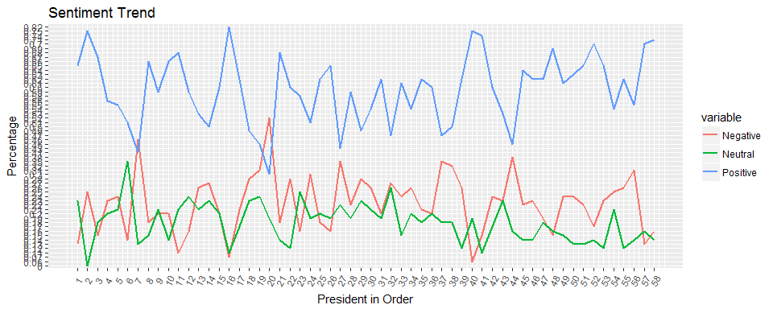

```r
ggplot(sentidata2,aes(x=Order, y=value, group=variable, col=variable))+geom_line(size=1)+labs(y="Percentage", x="President in Order",title="Sentiment Trend")+scale_x_continuous(breaks = seq(1,58,1))+ theme(axis.text.x=element_text(angle = 60, vjust = 0.5))
```

```r
orderdata$Preterm[7];orderdata$Preterm[20]
```

```
[1] James Madison2
58 Levels: Abraham Lincoln1 Abraham Lincoln2 Andrew Jackson1 Andrew Jackson2 Barack Obama1 ... Zachary Taylor1
[1] Abraham Lincoln2
58 Levels: Abraham Lincoln1 Abraham Lincoln2 Andrew Jackson1 Andrew Jackson2 Barack Obama1 ... Zachary Taylor1
```

### Specific sentiment analysis on inaugural speech of James Madison on his second term

```r
sometext=sent_detect(speeches.list$fullspeeches[7],
                        endmarks = c("?", ".", "!", "|",";"))
```

```r
# classify polarity
class_pol1 = classify_polarity(sometext, algorithm="bayes")
# get polarity best fit
polarity1 = class_pol1[,4]
```

```r
# data frame with results
sent_df1 = data.frame(text=sometext, polarity=polarity1, stringsAsFactors=FALSE)
```

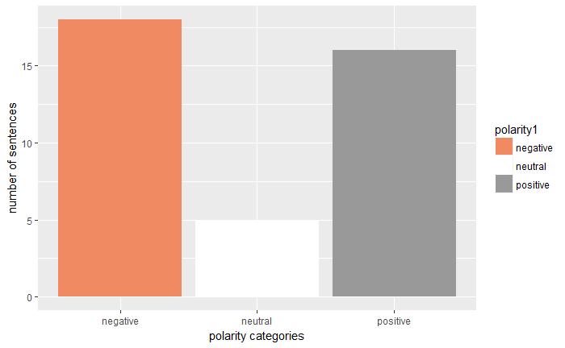

```r
# plot distribution of polarity
ggplot(sent_df1, aes(x=polarity1)) +
geom_bar(aes(y=..count.., fill=polarity1)) +
scale_fill_brewer(palette="RdGy") +
labs(x="polarity categories", y="number of sentences")
```

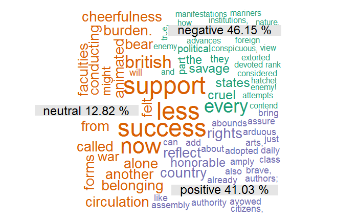

```r
# separating text by emotion
emos1 = levels(factor(sent_df1$polarity))
labels <- lapply(emos1, function(x) paste(x,format(round((length((sent_df1[sent_df1$polarity ==x,])$text)/length(sent_df1$polarity)*100),2),nsmall=2),"%"))
nemo1 = length(emos1)
emo.docs1 = rep("", nemo1)
for (i in 1:nemo1)
{
   tmp1 = sometext[polarity1 == emos1[i]]
   emo.docs1[i] = paste(tmp1, collapse=" ")
}
# remove stopwords
emo.docs1 = removeWords(emo.docs1, stopwords("english"))
# create corpus
corpus1 = Corpus(VectorSource(emo.docs1))
tdm1 = TermDocumentMatrix(corpus1)
tdm1 = as.matrix(tdm1)
colnames(tdm1) = labels
# comparison word cloud
comparison.cloud(tdm1, colors = brewer.pal(nemo1, "Dark2"),
   scale = c(3,.5), random.order = FALSE, title.size = 1.5)
```

In this plot, three colors represent three sentiments. Purple for positive, green for negative and orange for neutral. Also, there are sentiment labels followed by their corresponding percentage.

### Specific sentiment analysis on inaugural speech of Abraham Lincoln on his second term

```r
sometext=sent_detect(speeches.list$fullspeeches[20],
                        endmarks = c("?", ".", "!", "|",";"))
```

```r
# classify polarity
class_pol1 = classify_polarity(sometext, algorithm="bayes")
# get polarity best fit
polarity1 = class_pol1[,4]
```

```r
# data frame with results
sent_df1 = data.frame(text=sometext, polarity=polarity1, stringsAsFactors=FALSE)
```

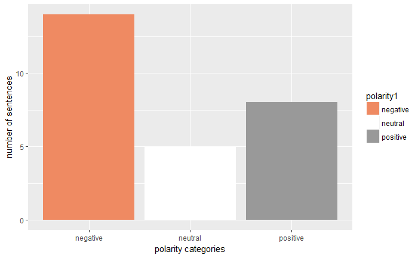

```r
# plot distribution of polarity
ggplot(sent_df1, aes(x=polarity1)) +
geom_bar(aes(y=..count.., fill=polarity1)) +
scale_fill_brewer(palette="RdGy") +
labs(x="polarity categories", y="number of sentences")
```

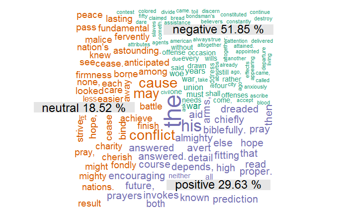

```r
# separating text by emotion
emos1 = levels(factor(sent_df1$polarity))
labels <- lapply(emos1, function(x) paste(x,format(round((length((sent_df1[sent_df1$polarity ==x,])$text)/length(sent_df1$polarity)*100),2),nsmall=2),"%"))
nemo1 = length(emos1)
emo.docs1 = rep("", nemo1)
for (i in 1:nemo1)
{
   tmp1 = sometext[polarity1 == emos1[i]]
   emo.docs1[i] = paste(tmp1, collapse=" ")
}
# remove stopwords
emo.docs1 = removeWords(emo.docs1, stopwords("english"))
# create corpus
corpus1 = Corpus(VectorSource(emo.docs1))
tdm1 = TermDocumentMatrix(corpus1)
tdm1 = as.matrix(tdm1)
colnames(tdm1) = labels
# comparison word cloud
comparison.cloud(tdm1, colors = brewer.pal(nemo1, "Dark2"),
   scale = c(3,.5), random.order = FALSE, title.size = 1.5)
```

There are some words such as “conflict”, “war”, “battle” which give us an idea that there may be a war. Actually, there is a war, that is called the Civil War and no wonder there are more negative words in his speech.